# Test pour le projet d’IF36 par Charlotte

Charlotte Sarter

2022-03-22

## Nettoyage des données

La première étape du projet est certainement une des plus importantes.

Nous avons commencé par analyser tous les datasets pour voir si les données nommées de la même manière correspondent à la même chose (ce qui n’était pas toujours le cas). Nous avons ensuite renommé toutes les colonnes de tous les datasets de la même manière selon la convention définie ci-dessous. Enfin, nous avons fusionné l’ensemble des datasets de manière à travailler sur un seul tableau propre à l’aide de filtres par la suite.

## Convention de nommage des colonnes

```
##  [1] "Country"                       "Region"
##  [3] "Happiness_rank"                "Happiness_score"
##  [5] "Standard_error"                "Exp_by_economy_gdp_per_capita"
##  [7] "Explained_by_social_support"   "Explained_by_life_expectancy"
##  [9] "Explained_by_freedom"          "Explained_by_trust_government"
## [11] "Explained_by_generosity"       "Dystopia_residual"
## [13] "lower_confidence_interval"     "upper_confidence_interval"
## [15] "Year"
```

```
##  [1] "Country"                       "Region"
##  [3] "Happiness_rank"                "Happiness_score"
##  [5] "Lower_confidence_interval"     "Upper_confidence_interval"
##  [7] "Exp_by_economy_gdp_per_capita" "Explained_by_social_support"
##  [9] "Explained_by_life_expectancy"  "Explained_by_freedom"
## [11] "Explained_by_trust_government" "Explained_by_generosity"
## [13] "Dystopia_residual"             "Standard_error"
## [15] "Year"
```

```
##  [1] "Country"                       "Happiness_rank"
##  [3] "Happiness_score"               "Upper_confidence_interval"
##  [5] "Lower_confidence_interval"     "Exp_by_economy_gdp_per_capita"
##  [7] "Explained_by_social_support"   "Explained_by_life_expectancy"
##  [9] "Explained_by_freedom"          "Explained_by_generosity"
## [11] "Explained_by_trust_government" "Dystopia_residual"
## [13] "Standard_error"                "Year"
```

```
##  [1] "Happiness_rank"                "Country"
##  [3] "Happiness_score"               "Exp_by_economy_gdp_per_capita"
##  [5] "Explained_by_social_support"   "Explained_by_life_expectancy"
##  [7] "Explained_by_freedom"          "Explained_by_generosity"
##  [9] "Explained_by_trust_government" "Year"
```

```
##  [1] "Happiness_rank"                "Country"
##  [3] "Happiness_score"               "Exp_by_economy_gdp_per_capita"
##  [5] "Explained_by_social_support"   "Explained_by_life_expectancy"
##  [7] "Explained_by_freedom"          "Explained_by_generosity"
##  [9] "Explained_by_trust_government" "Year"
```

```
##  [1] "Country"                       "Regional_indicator"
##  [3] "Happiness_score"               "Standard_error"
##  [5] "Upper_confidence_interval"     "Lower_confidence_interval"
##  [7] "Logged_gpd_per_capita"         "Social_support"
##  [9] "Life_expectancy"               "Freedom"
## [11] "Generosity"                    "Trust_government"
## [13] "Dystopia_score"                "Exp_by_economy_gdp_per_capita"
## [15] "Explained_by_social_support"   "Explained_by_life_expectancy"
## [17] "Explained_by_freedom"          "Explained_by_generosity"
## [19] "Explained_by_trust_government" "Dystopia_residual"
## [21] "Year"
```

```
##  [1] "Country"                       "Regional_indicator"
##  [3] "Happiness_score"               "Standard_error"
##  [5] "Upper_confidence_interval"     "Lower_confidence_interval"
##  [7] "Logged_gpd_per_capita"         "Social_support"
##  [9] "Life_expectancy"               "Freedom"
## [11] "Generosity"                    "Trust_government"
## [13] "Dystopia_score"                "Exp_by_economy_gdp_per_capita"
## [15] "Explained_by_social_support"   "Explained_by_life_expectancy"
## [17] "Explained_by_freedom"          "Explained_by_generosity"
## [19] "Explained_by_trust_government" "Dystopia_residual"
## [21] "Year"
```

## Est-ce que certaines régions du monde sont moins heureuses que d’autres ?

C’est ce que nous allons nous demander dans cette partie. Notre but est de déterminer si le bonheur a des préférences géographiques, et quels sont les critères qui rendent les populations de régions spécifiques plus heureuses que les autres.

## Idées de graphes à faire

1. Un barchart qui indique le nombre de pays dont on a les données par région
2. Un boxplot qui indique le score de bonheur de chaque région
3. Une carte du monde colorée par région en fonction du score de bonheur (avec ggmap ou leaflet)
4. Faire des scatterplots pour les différents critères en fonction du niveau de bonheur par région (moyenne sur toutes les années ou évolution dans le temps ?)

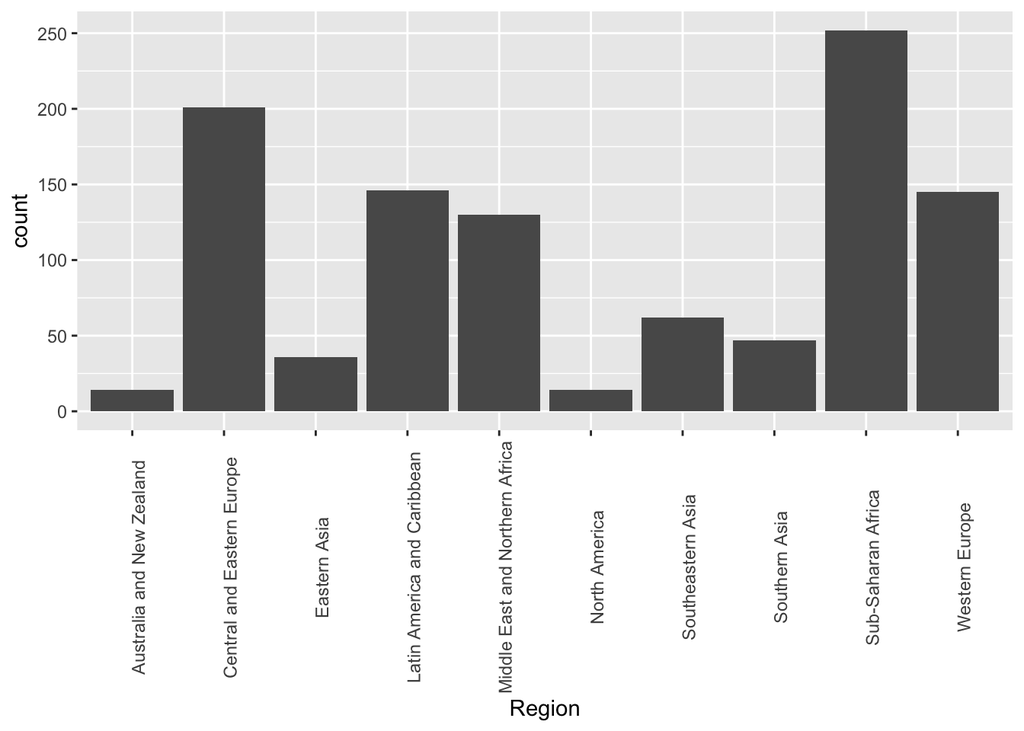

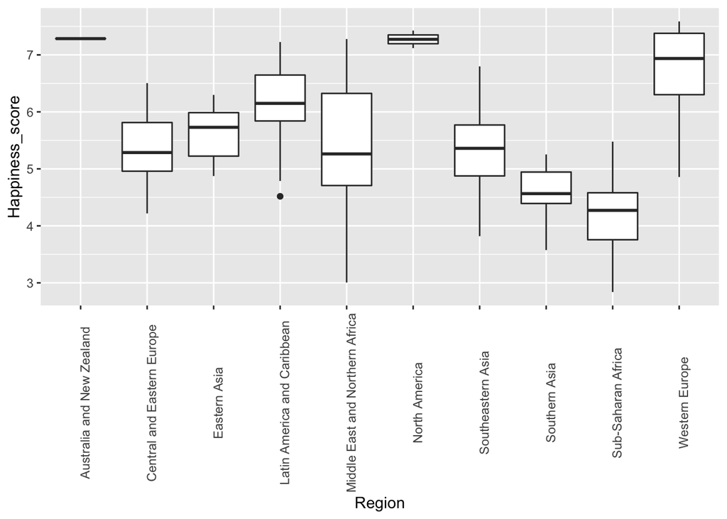

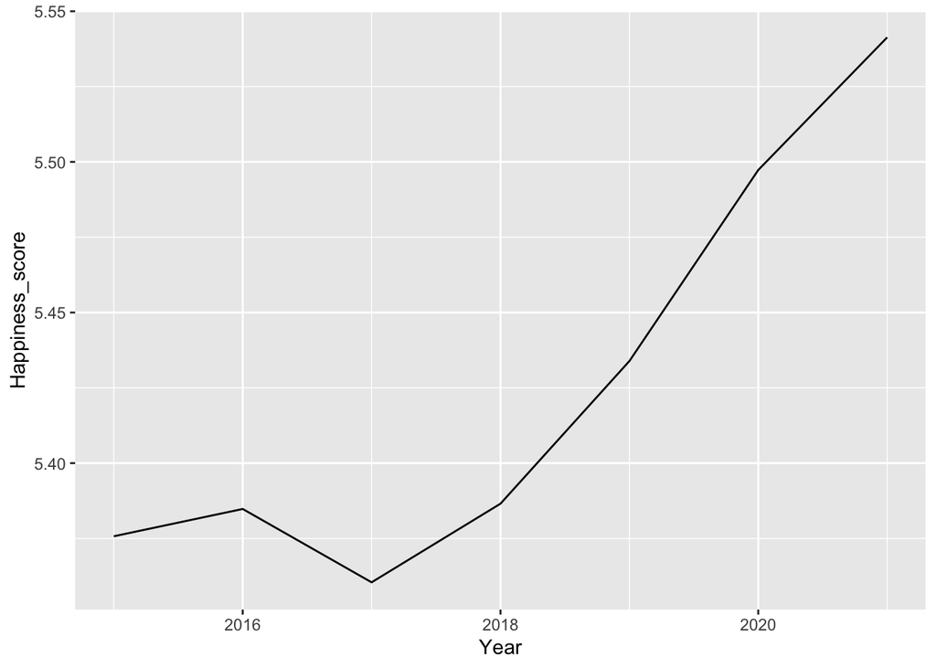

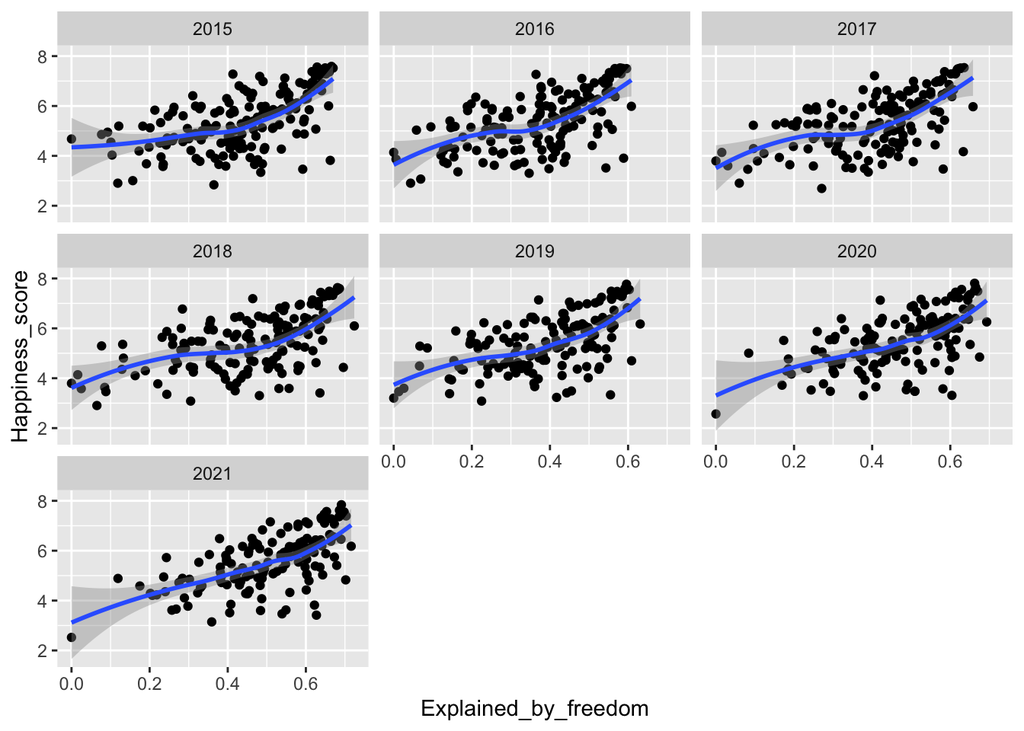

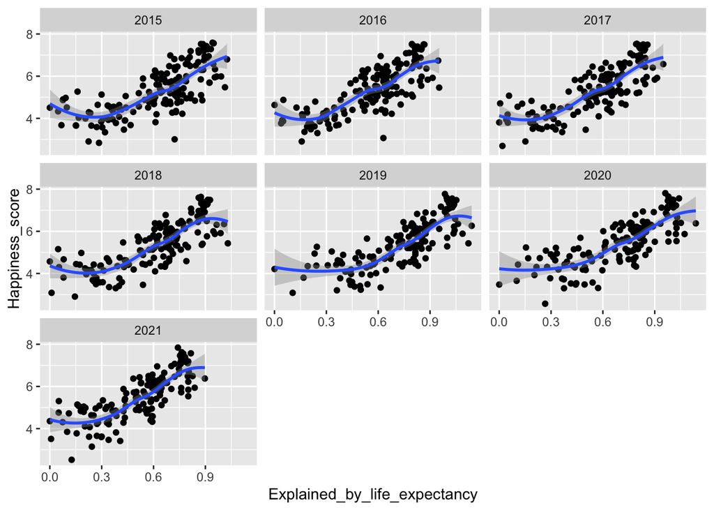

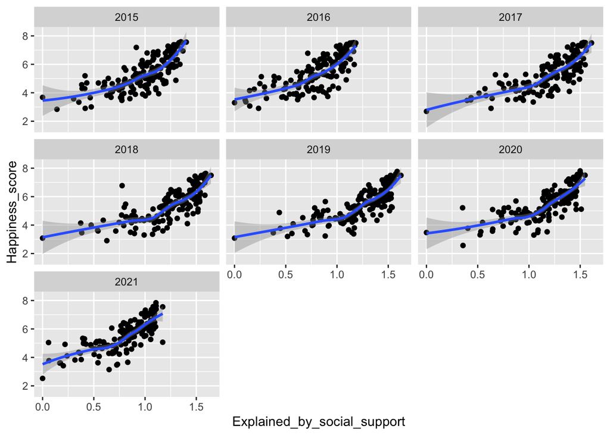

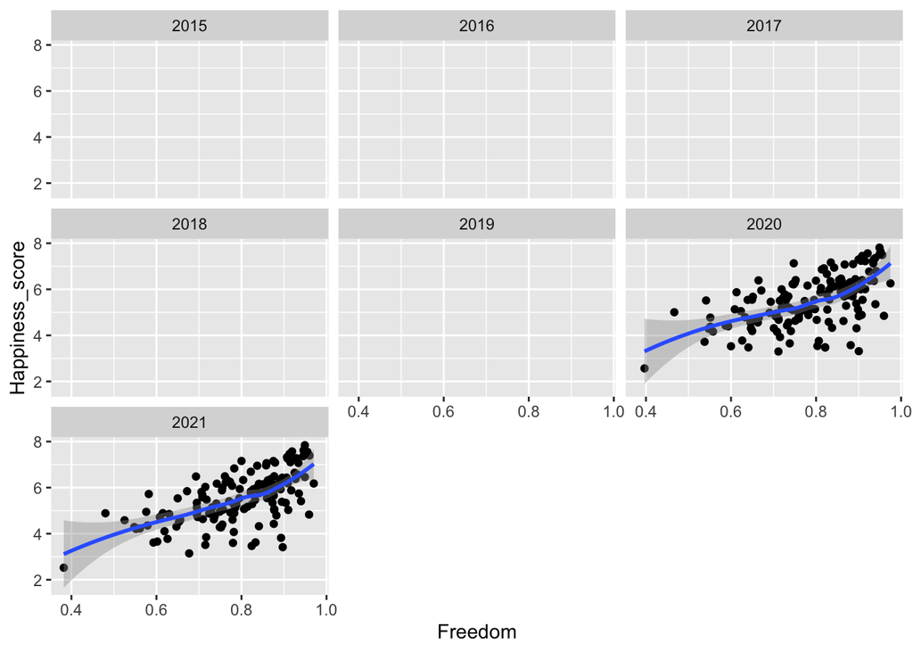